# Loading spatial data from tidycensus

The `tidycensus` package for R is a very convenient way to download census data along with associated boundaries. The author of the package has provided really excellent documentation [here](https://walker-data.com/tidycensus/), and you can find even more useful methods in his (free) ebook, [Analyzing US Census Data](https://walker-data.com/census-r/index.html).

# Required package

This skills page uses the following packages:

```r
library(tidycensus)
library(tidyverse)
library(sf)
library(here)
```

# Getting and installing a census API key

Before you can use the `tidycensus` package, you will need to register for a Census API key [here](https://api.census.gov/data/key_signup.html). It can take one or two business days to get a key, so do this well before the assignment is due.

Your API key will be a string of letters and numbers. If your API key is “1234567abcdEFG” (and it isn’t), you can install your API key by typing `census_api_key("1234567abcdEFG", install = TRUE)` into your console. You should only ever need to do this once.

# Selecting variables

When you download a set of polygons using `tidycensus`, you can select from many different variables to include with them. To see what your options are, you can type `View(load_variables(2020, "acs5"))` into your console. Of course, you can select a year other than 2020. “acs5” indicates that you want data from the 5-year sample of the American Community Survey. Alternatives are “acs1” for American Community Survey 1-year sample or “sf1” for the decennial census.

After you type that into your console, you’ll see a table like the one below. There is a search box at the top right (circled in red below) you can use to find a variable you’re interested in. The first column shows the variable name; the second and third columns describe the variable, and the fourth column shows the smallest census geography for which the variable is available.

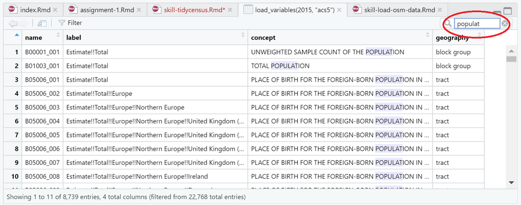

# Loading data

Let’s say I’m interested in the total population and the population of foreign-born residents for each census tract in San Luis Obispo County, California. I’ve determined that the variable name for total population is `B01003_001` and the variable name for the foreign-born population is `B05002_013`.

I can download the census tract boundaries for San Luis Obispo County along with the estimates and standard deviations for those two variables with the following code:

```r
vars <- c(total_pop = "B01003_001",
          foreign_pop = "B05002_013")

SLO_tracts <- get_acs(geography = "tract",
                      state = "CA",
                      county = "San Luis Obispo",
                      variables = vars,
                      output = "wide",
                      geometry = TRUE)
```

`output = "wide"` specifies that I want one row for each census tract and a column for each variable (the alternative is `output = "tidy"` which will rarely be what you want). `geometry = TRUE` indicates that you want the tract boundaries in addition to a table of the tract IDs and variables.

From there, you might choose to quickly plot the data within R (either using ggplot or leaflet) just to see what it looks like, or you might save it to another file format to work with it using different software.